# Week2

2/13/2022

## Step 1: Downloading, uncompressing and loading data

The following code lines download the file activity.zip from the url provided and unzip the file.

```r
# Defining the urlprovided from the task description:
urlProvided <-   "https://d396qusza40orc.cloudfront.net/repdata%2Fdata%2Factivity.zip"
# Downloading the file
download.file(urlProvided, destfile = "activity.zip")
# Unzip
unzip("activity.zip")
# load data
dataBase <- read.csv("activity.csv")
# Convert date to date format
dataBase$date <- as.Date(dataBase$date)
head(dataBase)
```

```
##   steps       date interval
## 1    NA 2012-10-01        0
## 2    NA 2012-10-01        5
## 3    NA 2012-10-01       10
## 4    NA 2012-10-01       15
## 5    NA 2012-10-01       20
## 6    NA 2012-10-01       25
```

## Step 2: Histogram of the total number of steps taken each day

Sum steps per day, then plot using hist.

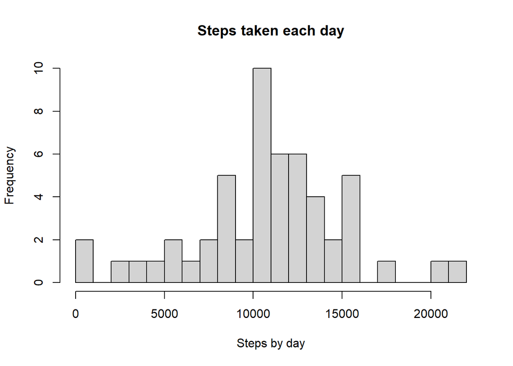

```r
stepsperday <- aggregate(dataBase$steps, list(Day = dataBase$date), FUN = sum )
hist(stepsperday$x, breaks = 20, main = "Steps taken each day", xlab = "Steps by day")
```

## Step 3: Mean and median number of steps taken each day

```r
mean(stepsperday$x, na.rm = TRUE)
```

```
## [1] 10766.19
```

```r
median(stepsperday$x, na.rm = TRUE)
```

```
## [1] 10765
```

## Step 4: Time series plot of the average number of steps taken

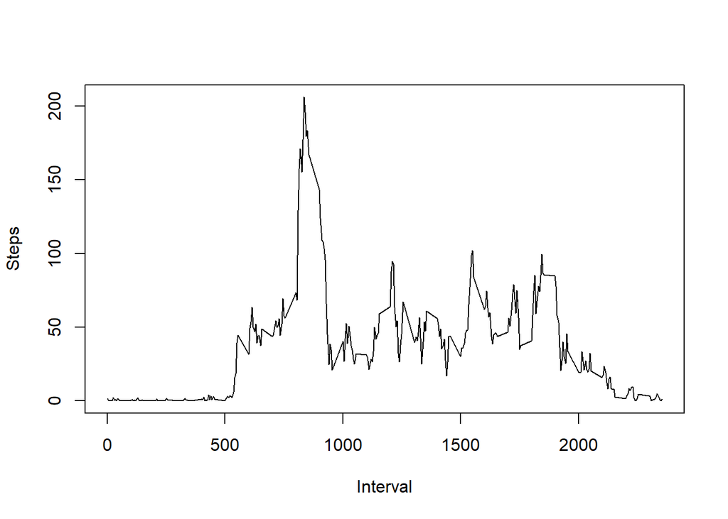

```r
filt_dataBase <- dataBase[ is.na(dataBase$steps) != TRUE , ]
stepsperinterval <- with(filt_dataBase, aggregate(steps, list(interval), FUN = mean ))
with(stepsperinterval, plot(Group.1, x, type = "l", xlab = "Interval", ylab = "Steps"))
```

## Step 5: The 5-min interval that contains the max steps

The 5-minute interval that, on average, contains the maximum number of steps.

```r
colnames(stepsperinterval) <- c("Interval", "Steps")
stepsperinterval[which(max(stepsperinterval$Steps)==stepsperinterval$Steps),]
```

```
##     Interval    Steps
## 104      835 206.1698
```

## Step 6: Strategy for imputing missing data

The original file imported contains a number of missing values (NA). The two easiest strategies for imputing missing data are:

- Using the the mean step value for the time interval
- or using the median step value for the time interval

### Total number of missing values in the dataset

```r
print(sum(is.na(dataBase)))
```

```
## [1] 2304
```

```r
print(sum(is.na(dataBase$steps)))
```

```
## [1] 2304
```

All the missing values are in the steps column.

### Filling in all of the missing values creating emputed table

```r
### Imputed Mean and Median
stepsperintMedian <- with(filt_dataBase, aggregate(steps, list(interval), FUN = median ))
imputedMean <- dataBase
imputedMedi <- dataBase
entriesdb   <- dim(dataBase)[1]
for ( i in seq(1,entriesdb)) {
  if (is.na(imputedMean$steps[i]==TRUE)) {

    imputedMean$steps[i] <-
      stepsperinterval$Steps[stepsperinterval$Interval == imputedMean$interval[i]]
    imputedMedi$steps[i] <-
      stepsperinterval$Steps[stepsperinterval$Interval == imputedMedi$interval[i]]
  }

}
### Calculating the sum per day using two types of emputed
### data
stepsdayMean <- aggregate(imputedMean$steps, list(Day = imputedMean$date), FUN = sum )
stepsdayMedi <- aggregate(imputedMedi$steps, list(Day = imputedMedi$date), FUN = sum )
```

### Step 7: Histogram of emputed data table

[figure not shown]

```r
par(mfrow = c(1,3))
hist(stepsperday$x, breaks = 20, main = "Original excluding #NA", xlab = "Steps by day")
hist(stepsdayMean$x, breaks = 20, main = "NA emputed with mean", xlab = "Steps by day")
hist(stepsdayMedi$x, breaks = 20, main = "NA emputed with median", xlab = "Steps by day")
```

```r
summary(stepsperday$x)
```

```
##    Min. 1st Qu.  Median    Mean 3rd Qu.    Max.    NA's
##      41    8841   10765   10766   13294   21194       8
```

```r
summary(stepsdayMean$x)
```

```
##    Min. 1st Qu.  Median    Mean 3rd Qu.    Max.
##      41    9819   10766   10766   12811   21194
```

```r
summary(stepsdayMedi$x)
```

```
##    Min. 1st Qu.  Median    Mean 3rd Qu.    Max.
##      41    9819   10766   10766   12811   21194
```

## Step 8:Activity patterns comparing weekdays and weekends?

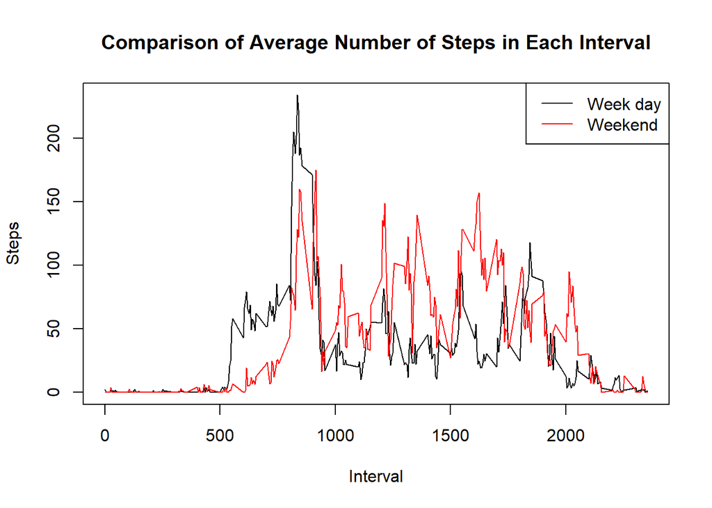

```r
####################################################################
# Step 8
####################################################################
filt_dataBase$weekday <- weekdays(filt_dataBase$date, abbreviate = TRUE)
filt_dataBase$weekend <- ifelse(filt_dataBase$weekday=="Sat" |
           filt_dataBase$weekday=="Sun", "Weekend", "Weekday" )
plot_data <- aggregate(filt_dataBase$steps,
                          list(filt_dataBase$interval, filt_dataBase$weekend),
                          FUN = mean)
colnames(plot_data) <- c("Interval", "Weeksplit", "Steps")
weekdayData <- plot_data[plot_data$Weeksplit == "Weekday", -2]
weekendData <- plot_data[plot_data$Weeksplit == "Weekend", -2]

par(mfrow = c(1,1))
plot(weekdayData$Interval, weekdayData$Steps, type = "l",
     col = "black", xlab = "Interval", ylab = "Steps",
     main = "Comparison of Average Number of Steps in Each Interval")
points(weekendData$Interval, weekendData$Steps, type = "l", col = "red")
legend("topright", lty = c(1,1), col = c("black", "red"), legend = c("Week day", "Weekend"))
```

## Step 9: R Code

All of the R code needed to reproduce the results (numbers, plots, etc.) are summarized in the sections above. The final compilation is made in the markdown filt. The R file is a working progress and the results were copied into the markdown file, which is used as a final depository for the work.